# Milestone 4

Diego Arias

Fifa 19 is the most popular soccer video game on the market is one of biggest parts of my college weekends. In addition to spending a lot of time playing FIFA with my roomates, I also love looking at FIFA databases and tracking how players have grown over the years. I am not yet sure in what scope this project will go, but as of now I am really enjoying looking at the data. For milestone #4 I looked at the 10 best soccer teams (according to Football Database) and used the Fifa 19 data that I loaded in to look at the age distributions of each of these teams. It was both really interesting and logical that Ajax had the lowest mean age out of the 10 teams since they are known for their top teir youth academy and for selling their stars to bigger teams once they get older.

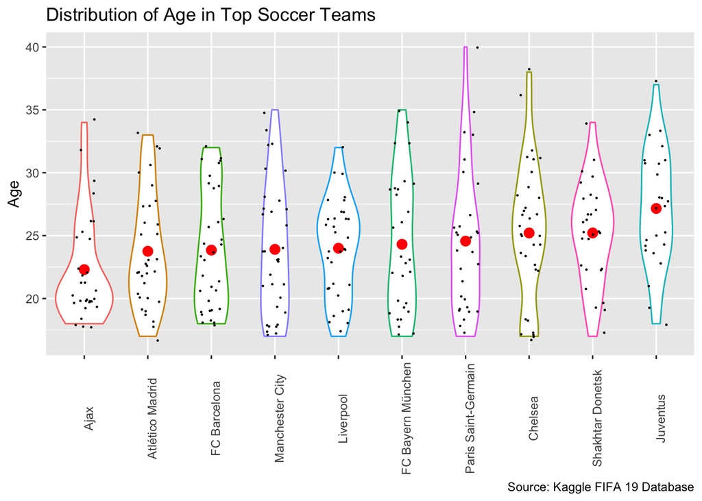

I then decided to modify the previous code to make a violin plot that instead analyzes the distribution of each team’s player rating. This motivates me to consider if I can later on measure the connection between teams’ age and rating distribtuion (since teams with more younger players should be lower in rating as those players have not yet hit their potential). One quick aside comment is that it is pretty interesting how plotting each individual player in the violin plot with a dot allows us to see some of the superstars. For example the highest rated players in Juventus and Barcelona are Ronaldo and Messi respectively.

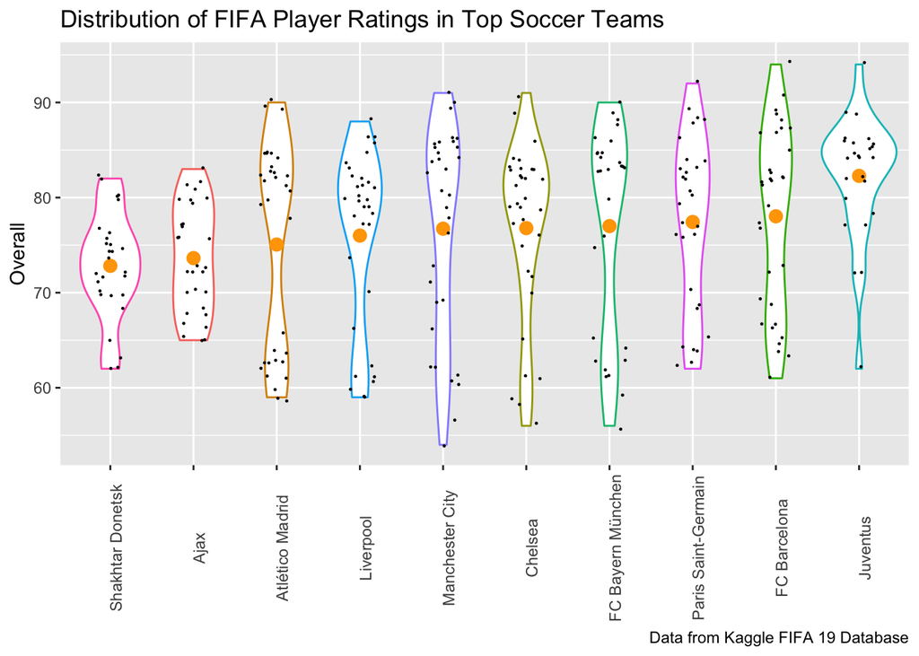